# R2BEAT workflow for Enumeration Areas as PSUs

Giulio Barcaroli

2023-03-26

## Problem definition

https://barcaroli.github.io/R2BEAT/articles/R2BEAT_workflow.html

https://barcaroli.github.io/R2BEAT/articles/R2BEAT_workflow_from_frame.html

In fact, the optimal allocation algorithm implemented in the function ‘beat.2st’ is based on an iterative procedure where at each iteration the threshold between self-representative and non self-representative can vary and hence also the best solution can vary, until convergence.

If the distribution of the measure of size is approximately uniform, as in the case of the Census Enumeration Areas, that are defined by trying to balance the number of dwellings and households, assumin that a previous round of the survey is available, the methodological approach should be changed in this way:

1. as usual, the input for the optimization step can be prepared by using the sample data of the previous round, in particular estimating for each sampling stratum and for each target variable, the mean and the standard deviation, together with the deff;
2. the standard deviations are inflated by multiplying them by the values of the square root of the deff;
3. given the precision constraints, the simple Bethel algorithm (implemented in the function ‘beat.1st’) is applied, obtaining the sample size and the allocations in the strata in terms of the Secondary Stage Units (SSUs);
4. the SSUs figures are divided by the required number of SSUs to be selected in each PSU, to obtain the corresponding sample size and allocations expressed in terms of PSUs.

Then, as usual it is possible to proceed to select the PSUs and the SSUs.

In the following a complete example of the above workflow will be illustrated.

## 1. Input data

We consider here the availability of two different input data:

1. a sampling frame (for instance, from a census) containing the whole set individuals included in teh population of interest, organized in SSUs (households) and in PSUs (Enumeration Areas);
2. a dataset originated by a previous round of the survey object of the sample design.

### 1.1 Sampling frame

```r
load("frame_pop_EA.RData")
str(frame_pop_EA)
```

```
## 'data.frame':    2217700 obs. of  18 variables:
##  $ id_MUN_EA    : num  1001 1001 1001 1001 1001 ...
##  $ id_hh        : Factor w/ 963018 levels "H1","H10","H100",..: 1 1 1 4447 4447 4447 4447 13336 13336 13336 ...
##  $ region       : Factor w/ 3 levels "north","center",..: 1 1 1 1 1 1 1 1 1 1 ...
##  $ province     : Factor w/ 6 levels "north_1","north_2",..: 1 1 1 1 1 1 1 1 1 1 ...
##  $ municipality : num  1 1 1 1 1 1 1 1 1 1 ...
##  $ id_ind       : int  1 2 3 19 20 21 22 50 51 52 ...
##  $ stratum      : Factor w/ 24 levels "1000","2000",..: 12 12 12 12 12 12 12 12 12 12 ...
##  $ stratum_label: chr  "north_1_6" "north_1_6" "north_1_6" "north_1_6" ...
##  $ sex          : int  1 2 1 2 2 1 2 2 2 1 ...
##  $ cl_age       : Factor w/ 8 levels "(0,14]","(14,24]",..: 3 7 8 5 2 3 8 3 5 5 ...
##  $ active       : num  1 1 0 1 1 1 0 0 1 1 ...
##  $ income_hh    : num  30488 30488 30488 28143 28143 ...
##  $ unemployed   : num  0 0 0 0 0 0 0 1 0 0 ...
##  $ inactive     : num  0 0 1 0 0 0 1 0 0 0 ...
##  $ id_EA        : num  1 1 1 1 1 1 1 1 1 1 ...
##  $ nsize_hh     : num  3 3 3 4 4 4 4 5 5 5 ...
##  $ rnd          : num  46478 46478 46478 191250 191250 ...
##  $ nfam_in_EA   : num  118 118 118 118 118 118 118 118 118 118 ...
```

```r
length(unique(frame_pop_EA$id_hh))
```

```
## [1] 945074
```

```r
length(unique(frame_pop_EA$id_MUN_EA))
```

```
## [1] 8239
```

So, we have 2,217,700 individuals in 945,074 households and 8,239 Enumeration Areas.

The EAs are well balanced in terms of the number of households:

```r
summary(frame_pop_EA$nfam_in_EA)
```

```
##    Min. 1st Qu.  Median    Mean 3rd Qu.    Max.
##    90.0   108.0   116.0   115.4   123.0   130.0
```

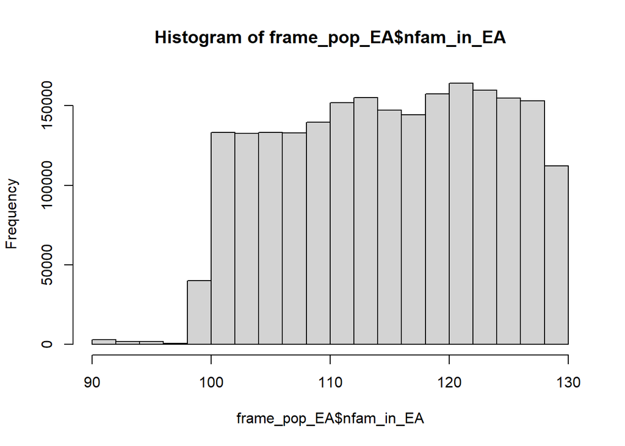

```r
hist(frame_pop_EA$nfam_in_EA)
```

### 1.2 Sample dataset

```r
load("sample.RData")
str(samp)
```

```
## 'data.frame':    9421 obs. of  20 variables:
##  $ id_MUN_EA    : Factor w/ 142 levels "1","4","6","8",..: 1 1 1 1 1 1 1 1 1 1 ...
##  $ id_ind       : int  11 19 34 67 141 166 170 191 208 308 ...
##  $ region       : Factor w/ 3 levels "north","center",..: 1 1 1 1 1 1 1 1 1 1 ...
##  $ province     : Factor w/ 6 levels "north_1","north_2",..: 1 1 1 1 1 1 1 1 1 1 ...
##  $ id_hh        : Factor w/ 963018 levels "H1","H10","H100",..: 1114 4447 10002 20002 45558 52224 54446 58891 63335 95557 ...
##  $ stratum      : Factor w/ 24 levels "1000","2000",..: 12 12 12 12 12 12 12 12 12 12 ...
##  $ stratum_label: chr  "north_1_6" "north_1_6" "north_1_6" "north_1_6" ...
##  $ sex          : int  2 2 2 1 1 1 1 2 1 2 ...
##  $ cl_age       : Factor w/ 8 levels "(0,14]","(14,24]",..: 3 5 5 5 1 1 1 8 1 1 ...
##  $ active       : num  1 1 0 1 0 0 0 0 0 0 ...
##  $ income_hh    : num  17043 28143 4791 28043 27185 ...
##  $ unemployed   : num  0 0 1 0 0 0 0 0 0 0 ...
##  $ inactive     : num  0 0 0 0 1 1 1 1 1 1 ...
##  $ Prob_1st     : num  0.187 0.187 0.187 0.187 0.187 ...
##  $ Prob_2st     : num  0.0323 0.0323 0.0323 0.0323 0.0323 ...
##  $ Prob_tot     : num  0.00604 0.00604 0.00604 0.00604 0.00604 ...
##  $ weight       : num  166 166 166 166 166 ...
##  $ SR           : num  0 0 0 0 0 0 0 0 0 0 ...
##  $ nSR          : num  1 1 1 1 1 1 1 1 1 1 ...
##  $ stratum_2    : chr  "12000-2" "12000-2" "12000-2" "12000-2" ...
```

Using the ReGenesees function, we define the sample design:

```r
samp$stratum_2 <- as.factor(samp$stratum_2)
sample.des <- e.svydesign(samp,
                          ids= ~ id_MUN_EA + id_hh,
                          strata = ~ stratum_2,
                          weights = ~ weight,
                          self.rep.str = ~ SR,
                          check.data = TRUE)
```

```
##
## # Empty levels found in factors: id_hh
## # Empty levels have been dropped!
```

Find and collapse lonely strata:

```r
ls <- find.lon.strata(sample.des)
```

```
## # No lonely PSUs found!
```

```r
if (!is.null(ls)) sample.des <- collapse.strata(sample.des)
```

and calibrate with known totals:

```r
totals <- pop.template(sample.des,
                       calmodel = ~ sex : cl_age,
                       partition = ~ region)
totals <- fill.template(frame_pop_EA, totals, mem.frac = 10)
```

```
##
## # Empty levels found in factors: id_hh
## # Empty levels have been dropped!
##
##
## # Coherence check between 'universe' and 'template': OK
```

```r
sample.cal <- e.calibrate(sample.des,
                          totals,
                          calmodel = ~ sex : cl_age,
                          partition = ~ region,
                          calfun = "logit",
                          bounds = c(0.3, 2.6),
                          aggregate.stage = 2,
                          force = FALSE)
```

## 2. Input preparation for allocation step

```r
samp_frame <- frame_pop_EA
RGdes <- sample.des
RGcal <- sample.cal
strata_var <- c("stratum")
target_vars <- c("income_hh",
                 "active",
                 "inactive",
                 "unemployed")
weight_var <- "weight"
deff_var <- "stratum"
id_PSU <- c("id_MUN_EA")
id_SSU <- c("id_hh")
domain_var <- c("region")
delta <- length(unique(samp_frame$id_ind)) / length(unique(samp_frame$id_hh))
minimum <- 24

inp <- prepareInputToAllocation2(
  samp_frame,  # sampling frame
  RGdes,       # ReGenesees design object
  RGcal,       # ReGenesees calibrated object
  id_PSU,      # identification variable of PSUs
  id_SSU,      # identification variable of SSUs
  strata_var,  # strata variables
  target_vars, # target variables
  deff_var,    # deff variables
  domain_var,  # domain variables
  delta,       # Average number of SSUs for each selection unit
  minimum      # Minimum number of SSUs to be selected in each PSU
)
```

## 3. Allocation step

We consider the strata and the deff:

```r
strata <- inp$strata
deff <- inp$deff
```

and inflate the standard deviations of the estimates in strata with the square root of the deff:

```r
strata2 <- strata
strata2$S1 <- strata$S1 * sqrt(deff$DEFF1)
strata2$S2 <- strata$S2 * sqrt(deff$DEFF2)
strata2$S3 <- strata$S3 * sqrt(deff$DEFF3)
strata2$S4 <- strata$S4 * sqrt(deff$DEFF4)
```

We set the precision constraints:

```r
cv <- as.data.frame(list(DOM=c("DOM1","DOM2"),
                         CV1=c(0.02,0.03),
                         CV2=c(0.03,0.06),
                         CV3=c(0.03,0.06),
                         CV4=c(0.05,0.08)))
cv
```

```
##    DOM  CV1  CV2  CV3  CV4
## 1 DOM1 0.02 0.03 0.03 0.05
## 2 DOM2 0.03 0.06 0.06 0.08
```

We can now apply the Bethel algorithm:

```r
alloc <- beat.1st(stratif = strata2, errors = cv)
sum(alloc$n)
```

```
## [1] 9171
```

which is higher with respect to the case with non-inflated standard deviations:

```r
alloc_no_deff <- beat.1st(stratif = strata, errors = cv)
sum(alloc_no_deff$n)
```

```
## [1] 8052
```

These are the expected values of the CVs under this allocation (together with sensitivity):

```r
# source("sens_names.R")
sens_names(s=alloc$sensitivity,
           target_vars=target_vars,
           strata=strata2)
```

```
##    Type    Dom        Var Planned CV Actual CV Sensitivity 10%
## 2  DOM1  Total  income_hh       0.02    0.0117               1
## 3  DOM1  Total     active       0.03    0.0107               1
## 4  DOM1  Total   inactive       0.03    0.0278               1
## 5  DOM1  Total unemployed       0.05    0.0463               1
## 6  DOM2  north  income_hh       0.03    0.0163               1
## 7  DOM2  north     active       0.06    0.0072               0
## 8  DOM2  north   inactive       0.06    0.0242               1
## 9  DOM2  north unemployed       0.08    0.0800            1288
## 10 DOM2 center  income_hh       0.03    0.0201               1
## 11 DOM2 center     active       0.06    0.0216               1
## 12 DOM2 center   inactive       0.06    0.0599             324
## 13 DOM2 center unemployed       0.08    0.0775               1
## 14 DOM2  south  income_hh       0.03    0.0299              35
## 15 DOM2  south     active       0.06    0.0398               1
## 16 DOM2  south   inactive       0.06    0.0599             187
## 17 DOM2  south unemployed       0.08    0.0651               1
```

## 4. Sample selection

### 4.1 Selection of the Enumeration Areas

In order to determine the allocation of the PSUs on the basis of the allocation of SSUs, we first refine the definition of the DELTA (average number of indivuals per household), by calculating its values differentiated in each stratum:

```r
des_file <- inp$des_file
des_file$DELTA <- with(samp_frame, tapply(id_ind, list(stratum), function(x) length(unique(x)))) /
  with(samp_frame, tapply(id_hh, list(stratum), function(x) length(unique(x))))
des_file
```

```
##    STRATUM STRAT_MOS    DELTA MINIMUM
## 1     1000    196791 2.484013      24
## 2     2000    260412 2.366951      24
## 3     3000    113373 2.351405      24
## 4     4000     15654 2.199522      24
## 5     5000    101036 2.320906      24
## 6     6000     47036 2.235445      24
## 7     7000     29671 2.253950      24
## 8     8000     24985 2.190322      24
## 9     9000     92780 2.303834      24
## 10   10000    105327 2.199628      24
## 11   11000    200757 2.392328      24
## 12   12000     53612 2.396067      24
## 13   13000    102907 2.382768      24
## 14   14000     83901 2.216613      24
## 15   15000    182788 2.252915      24
## 16   16000     99781 2.191255      24
## 17   17000     61117 2.562773      24
## 18   18000     73806 2.534025      24
## 19   19000    137396 2.392866      24
## 20   20000     57063 2.197181      24
## 21   21000     54926 2.607948      24
## 22   22000     41362 2.422939      24
## 23   23000     70811 2.383968      24
## 24   24000     10408 2.082433      24
```

We can now proceed to select the sample of PSUs:

```r
# source("select_PSU2.R")
psu_file <- inp$psu_file
PSU_sample <- select_PSU2(alloc=alloc,
                    type="ALLOC",
                    des_file=des_file,
                    psu_file=psu_file)
```

```
##
##  Stratum:  1000   PSUs to be selected:  5   PSUs selected:  5
##  Stratum:  2000   PSUs to be selected:  13   PSUs selected:  13
##  Stratum:  3000   PSUs to be selected:  4   PSUs selected:  4
##  Stratum:  4000   PSUs to be selected:  1   PSUs selected:  1
##  Stratum:  5000   PSUs to be selected:  3   PSUs selected:  3
##  Stratum:  6000   PSUs to be selected:  3   PSUs selected:  3
##  Stratum:  7000   PSUs to be selected:  1   PSUs selected:  1
##  Stratum:  8000   PSUs to be selected:  1   PSUs selected:  1
##  Stratum:  9000   PSUs to be selected:  10   PSUs selected:  10
##  Stratum:  10000   PSUs to be selected:  10   PSUs selected:  10
##  Stratum:  11000   PSUs to be selected:  20   PSUs selected:  20
##  Stratum:  12000   PSUs to be selected:  9   PSUs selected:  9
##  Stratum:  13000   PSUs to be selected:  13   PSUs selected:  13
##  Stratum:  14000   PSUs to be selected:  11   PSUs selected:  11
##  Stratum:  15000   PSUs to be selected:  23   PSUs selected:  23
##  Stratum:  16000   PSUs to be selected:  20   PSUs selected:  20
##  Stratum:  17000   PSUs to be selected:  2   PSUs selected:  2
##  Stratum:  18000   PSUs to be selected:  2   PSUs selected:  2
##  Stratum:  19000   PSUs to be selected:  7   PSUs selected:  7
##  Stratum:  20000   PSUs to be selected:  2   PSUs selected:  2
##  Stratum:  21000   PSUs to be selected:  2   PSUs selected:  2
##  Stratum:  22000   PSUs to be selected:  1   PSUs selected:  1
##  Stratum:  23000   PSUs to be selected:  3   PSUs selected:  3
##  Stratum:  24000   PSUs to be selected:  1   PSUs selected:  1
```

This are the results:

```r
head(PSU_sample$sample_PSUs,20)
```

```
##      STRATUM PSU_ID PSU_MOS     pik_1st PSU_final_sample_unit    pik_2st
## 105     1000 309105     284 0.007215777                    24 0.08450704
## 245     1000 330058     280 0.007114146                    24 0.08571429
## 379     1000 330192     252 0.006402732                    24 0.09523810
## 515     1000 330328     269 0.006834662                    24 0.08921933
## 650     1000 330463     300 0.007622300                    24 0.08000000
## 709    10000   4021     260 0.024685029                    24 0.09230769
## 749    10000  11012     262 0.024874913                    24 0.09160305
## 789    10000  11052     286 0.027153531                    24 0.08391608
## 829    10000  13021     273 0.025919280                    24 0.08791209
## 871    10000  40007     247 0.023450777                    24 0.09716599
## 911    10000  40047     250 0.023735604                    24 0.09600000
## 953    10000  41029     248 0.023545720                    24 0.09677419
## 996    10000  51030     261 0.024779971                    24 0.09195402
## 1039   10000  51073     368 0.034938810                    24 0.06521739
```

[output cut: 27 more lines]

It is interesting to notice that the sample in each stratum is self-weighted (weights have equal weights).

```r
PSU_sample$PSU_stats
```

```
##    STRATUM PSU  SSU DELTA Units
## 1     1000   5  120  2.48   298
## 2     2000  13  312  2.37   738
## 3     3000   4   96  2.35   226
## 4     4000   1   24   2.2    53
## 5     5000   3   72  2.32   167
## 6     6000   3   72  2.24   161
## 7     7000   1   24  2.25    54
## 8     8000   1   24  2.19    53
## 9     9000  10  240   2.3   553
## 10   10000  10  240   2.2   528
## 11   11000  20  480  2.39  1148
## 12   12000   9  216   2.4   518
## 13   13000  13  312  2.38   743
## 14   14000  11  264  2.22   585
## 15   15000  23  552  2.25  1244
## 16   16000  20  480  2.19  1052
## 17   17000   2   48  2.56   123
## 18   18000   2   48  2.53   122
## 19   19000   7  168  2.39   402
## 20   20000   2   48   2.2   105
## 21   21000   2   48  2.61   125
## 22   22000   1   24  2.42    58
## 23   23000   3   72  2.38   172
## 24   24000   1   24  2.08    50
## 25    <NA> 167 4008  2.31  9278
```

The sum of the inverse of the probabilities of inclusion of the first stage almost reproduce the true value in the frame (8,239):

```r
sum(1/PSU_sample$sample_PSUs$pik_1st)
```

```
## [1] 8264.97
```

### 4.2 Selection of the households

Finally, we can select the sample of households:

```r
# source("select_SSU.R")
PSU_sample$sample_PSUs$Pik <- PSU_sample$sample_PSUs$pik_1st
samp <- select_SSU(df=samp_frame,
                   PSU_code="id_MUN_EA",
                   SSU_code="id_hh",
                   PSU_sampled=PSU_sample$sample_PSU,
                   verbose=FALSE)
```

```
##
## --------------------------------
## Total PSU =  167
## Total SSU =  4008
## Total Units =  9288
## --------------------------------
```

```r
head(samp)
```

```
##     id_hh id_MUN_EA region province municipality  id_ind stratum stratum_label
## 1 H100103     40007  north  north_1        40007 1486366   10000     north_1_4
## 2 H100180     40007  north  north_1        40007 1486559   10000     north_1_4
## 3 H100180     40007  north  north_1        40007 1486560   10000     north_1_4
## 4 H100180     40007  north  north_1        40007 1486561   10000     north_1_4
## 5 H100256     40007  north  north_1        40007 1486732   10000     north_1_4
## 6 H100256     40007  north  north_1        40007 1486733   10000     north_1_4
##   sex  cl_age active income_hh unemployed inactive id_EA nsize_hh      rnd
## 1   1 (34,44]      1  19148.94          0        0     7        1 108377.6
## 2   1 (14,24]      1  34988.99          0        0     7        3 104054.9
## 3   1 (54,64]      1  34988.99          0        0     7        3 104054.9
## 4   2 (44,54]      1  34988.99          0        0     7        3 104054.9
## 5   1 (34,44]      1  38139.38          0        0     7        3 112889.4
## 6   1  (0,14]      0  38139.38          0        1     7        3 112889.4
##   nfam_in_EA   Prob_1st  Prob_2st    Prob_tot   weight
## 1        107 0.02345078 0.2388664 0.005601603 178.5203
## 2        107 0.02345078 0.2388664 0.005601603 178.5203
## 3        107 0.02345078 0.2388664 0.005601603 178.5203
## 4        107 0.02345078 0.2388664 0.005601603 178.5203
## 5        107 0.02345078 0.2388664 0.005601603 178.5203
## 6        107 0.02345078 0.2388664 0.005601603 178.5203
```

The sum of the weights perfectly eqaulizes the number of individuals in the sampling frame (2,217,700):

```r
sum(samp$weight)
```

```
## [1] 2217700
```